# Metabolism explainer

Jeffrey A. Walker

29 March, 2022

# Catabolism and ATP synthesis

**Catabolism** is the subset of metabolism that includes the breakdown of big molecules to small molecules. But typically when a physiologist is talking about catabolic pathways, they are referring to the pathways for ATP synthesis. Another term used alot is **oxidiation**, for example “the oxidation of glucose” or the “oxidation of fatty acids”. Oxidation reactions are one half of coupled **oxidation-reduction (redox)** reactions. In these reactions, energy is transferred from one substrate to the other, ultimately in the form of an electron (e-). The substrate that gives up the e- is **oxidized**. The substrate that receives the electron is **reduced**. So when we say “the oxidation of glucose” we mean the set of reactions that remove energy from glucose and pass it along but this is always in the context of ultimately using this energy to synthesize ATP.

The major fuels for ATP synthesis are glucose, fatty acids (FA), and to a lesser extent, amino acids (also alcohol if you drink alot). Let’s focus on oxidation of glucose and FA.

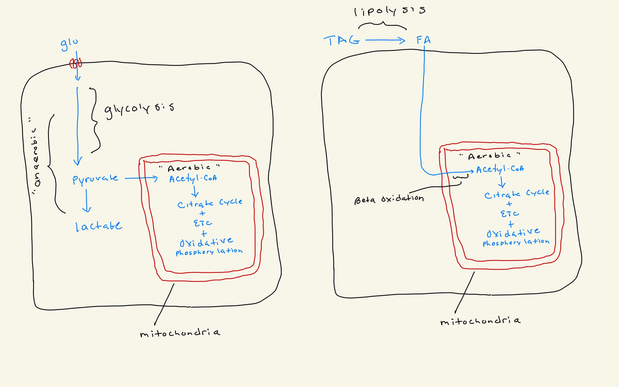

The big picture for glucose is that it is 1) oxidized to pyruvate in the cytosol in a process called **glycolysis**. This generates a little bit of ATP. There is still a bunch of energy left in pyruvate and one fate of pyruvate is to diffuse into the mitochondria and be fully oxidized to CO2 and H2O. The first step of this is the oxidation of pyruvate to **acetyl-coA**. Acetyl-coA is a super important “hub” molecule with many fates but one fate is that it is an inital substrate for **aerobic pathway** for ATP synthesis which includes different “parts”: **citrate cycle**, **electron transport**, and **oxidative phosphorylation**. The arobic pathway generates a lot of ATP.

The big picture for FA is that these are transported into the mitochondria and are oxided to acetyl-CoA in a process called **beta-oxidation**. **Acetyl-CoA** then enters the aerobic pathway for ATP synthesis.

**Conception/Misconception** – Many students have the wrong working definition of **anaerobic** and most textbooks (even very good textbooks) actively encourage this misconception. Glycolysis generates a small amount of ATP and is an **anaerobic** pathway because O2 is not a substrate in any of the reactions. Many students and even instructors think anaerobic means the cell has no O2. Cells always have abundant O2 (unless you are George Clooney at the end of the movie Gravity - where he floats off into space). The pathway for ATP synthesis in the mitochondria is called **aerobic** because O2 is a substrate. The aerobic pathway is also called **respiration** or **cellular respiration**.

A concept that is here to stay but is a terrible name is **anaerobic respiration** for the path glucose -> lactate, a name that is used in exercise physiology and cancer biology (I would call the glucose -> lactate path **anaerobic path for ATP synthesis** but an even better name is **fermentation**). The reason anaerobic respiration is a terrible name is because “respiration” implies an electron transport chain that generates an ion gradient to synthsize ATP and some kind of “final electron acceptor” such as (but not necessarily) O2. So glucose -> lactate is not “respiration”. True anaerobic respiration exists in some bacteria but this isn’t the path glucose -> lactate.

# Lactate

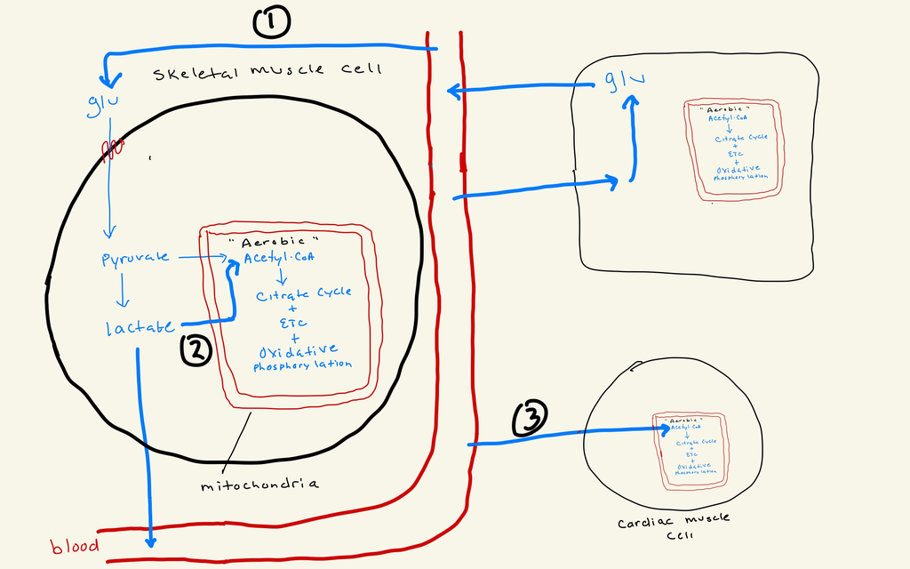

# Glucose stress

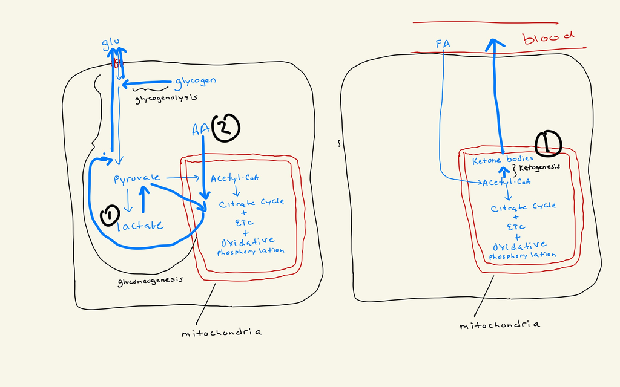

In the fasting state (a few hours after a meal), our blood glucose levels are low and **glucagon**, **cortisol**, and **norepinephrine** are released to raise blood glucose by 1) **glycogenolysis** (“break apart glycogen”) – the breakdown of stored glycogen to glucose, primarily in liver hepatocytes. The glucose is secreted into the blood. Skeletal muscle cells store glycogen and break it down to glucose but they use the glucose and don’t secrete it into the blood. 2) **gluconeogenesis** (“the birth of new glucose”). The primary gluconeogenic substrate is lactate (#1 in the lactate image) but some amino acids are also gluconeogenic. Most gluconeogenesis is by liver hepatocytes.

Another consequence of low blood glucose is **ketogenesis** (“the birth of keto”). With low blood glucose, there is signaling for lipolysis to increase blood FA for ATP synthesis. The Acetyl Co-A from beta-oxidation has two fates 1) into citrate-cycle/ETC/oxidative phosphorylation (aerobic pathway), and 2) the synthesis of **ketone bodies**, which are secreted into the blood. Brain tissue does not use FA for ATP synthesis but uses the glucose from liver glycogenolysis/gluconeogenesis and ketone bodies from liver hepatocytes.

That is, ketogenesis is a normal stress response to low blood glucose during fasting and is good. In uncontrolled diabetes, where skeletal muscle cells are using FA for ATP synthesis because they cannot transport glucose, there is not enough substrate for ATP synthesis (because pyruvate from glucose is converted into both substrates for the citrate cycle but beta oxidation only creates one) and there is excessive ketogenesis which raises ketone body levels in the blood. This is called **ketoacidosis** and it is lethal.

**Conception/Misconception** – When Dr. Atkins first proposed the Atkins diet, which is an extremely low carb diet, most doctors thought he was crazy and that all Atkins dieters would die from ketoacidosis because of excessive FA catabolism. This didn’t happen. The reason is obvious in hindsight – People on Atkins diet who are not Type I diabetics have a functioning insulin signaling system and the path to ketogenesis is less favorable than the path to the citrate cycle.

# An excess of energy

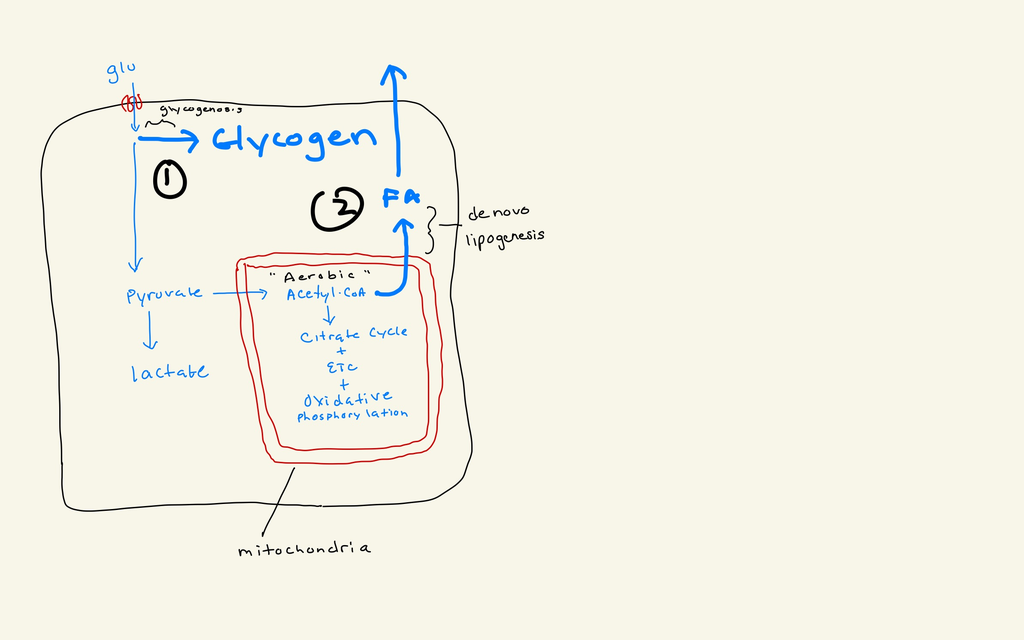

If we take in more energy than we use, the excess energy is stored as TAGs in adipose tissue. This makes sense if the excess energy comes from a “high fat” diet. But this can also happen in a “high carb” diet. If we have excessive glucose (more than our cells need or can be stored as glycogen) then the glucose is converted to FA and stored as TAGs. This is called **de novo lipogenesis** (“the birth of fat from something new”). Essentially, the glucose is oxidized to acetyl co-A and because the cells are ATP balanced, the acetyl-co-A enters reactions that are the reverse of beta-oxidation.

**Conception/Misconception** – when I was a kid, a common phrase on posters was “you are what you eat”. The idea was, if you eat a bunch of junk, your body will be junk. The health community heavily promoted the idea that if you eat a bunch of fat then you will be fat so this was the beginning of low-fat diets. What the health community failed to recognize is that we aren’t what we eat. Stuff like de novo lipogeneisis happens. Its not what we eat but how much we eat. It’s super easy to over-eat bread and pasta and all this excessive calories as carbs was converted to stored TAGs by de novo lipogenesis. Oops.